# LabWork2

## Introduction to Machine Learning - LabWork-2 - Mercan Karacabey

```python
"""BDA502 SPRING 2018-19

- Gaussian Naive Bayes
- Support Vector Machines

TASK-1: Please explain how the Naive Bayesian algorithm work very briefly by using the example below.

TASK-2: Please use the small dataset about gender classification with Gaussian Naive Bayes.

TASK-3: Please use the digits dataset with comparing Gaussian Naive Bayes and Support Vector Machine algorithms.

TASK-4: Illustrate a linear and non-linear SVM model with plots. You need to find a suitable example, run it and explain it.

"""
```

```
'BDA502 SPRING 2018-19\n\n- Gaussian Naive Bayes\n- Support Vector Machines\n\nTASK-1: Please explain how the Naive Bayesian algorithm work very briefly by using the example below.\n\nTASK-2: Please use the small dataset about gender classification with Gaussian Naive Bayes.\n\nTASK-3: Please use th…
```

### TASK-1: Simple Example for GaussianNB from scikit-learn

x -> features y -> labels

GaussianNB algorithm -- Classification Algorithm We have two sets. 1 and 2 . Then we want to show that new value is which set. fit function -- run the gaussian method for A dataset and B sets.

1- Class prior value - Which set is appropriate for new values? And close which set. 2- Class Count value - During the training step , how much class was generated? 3- Score function - Algorithm and training result for new values

In the below code, I calculated time difference of fit the algorithm GaussianNB.

```python
import time
start = time.time()
import numpy as np
X = np.array([[-1, -1], [-2, -1], [-3, -2], [1, 1], [2, 1], [3, 2]])
Y = np.array([1, 1, 1, 1, 2, 2])
from sklearn.naive_bayes import GaussianNB
clf = GaussianNB(priors=None)
clf.fit(X, Y) # GaussianNB(priors=None)
done = time.time()
elapsed = done - start
print(elapsed)
```

```
0.0019979476928710938
```

Time difference : 0.0019

GaussianNB is a classification algorithm. Calculate probability value and decide which set is appropriate for value depends on probability value

```python
print(clf.predict([[-0.8, -1]]))
print(clf.class_prior_)  # probability of each class.
print(clf.class_count_)  # number of training samples observed in each class.
print(clf.theta_)  # mean of each feature per class.
print(clf.sigma_)  # variance of each feature per class
print(clf.predict_proba([[0.8, 1]]))  # Return probability estimates for the test vector X.
print(clf.predict_log_proba([[0.8, 1]]))  # Return log-probability estimates for the test vector X.
print(clf.score([[0.8, 1]],[1]))  # Returns the mean accuracy on the given test data and labels.
print(clf.score([[0.8, 1]],[2]))  # Returns the mean accuracy on the given test data and labels.
```

```
[1]
[0.66666667 0.33333333]
[4. 2.]
[[-1.25 -0.75]
 [ 2.5   1.5 ]]
[[2.1875 1.1875]
 [0.25   0.25  ]]
[[0.94580782 0.05419218]]
[[-0.05571588 -2.91521869]]
1.0
0.0
```

Predict function - Guess the set 1 or set 2.

Class-Prior Value - Dataset density based on count set1 and set2

Class-Count Value - Count set1 and set2

Theta Value - Mean Value of each class

Sigma Value - Variance of each class

Score function - Shows that accuracy rate for given value.

#### Interpretation Results

Predict Function Result : 1 => Given value is in First Set.

Class Prior Value : 0.66 / 0.33 => In the set, Count of 1 : 4/6 Count of 2 : 2/6

Score Function : 1.0 / 0.0 => Given value: Is 0.8, 1 in [1] ? Yes given value is in set 1. TRUE 1.0

And against to this => FALSE 0.0

### TASK-2: Please use the small dataset about gender classification with Gaussian Naive Bayes and compare the results.

http://www.wikizero.biz/index.php?q=aHR0cHM6Ly9lbi53aWtpcGVkaWEub3JnL3dpa2kvTmFpdmVfQmF5ZXNfY2xhc3NpZmllcg

```python
## Height, Weight and Foot Size is input and we access to new variable in which set.
## It has done Probability based estimation. This algorithm creates continuous function and trains.
## Naive Bayes classifiers are a family of simple "probabilistic classifiers" based on applying Bayes' theorem with strong (naive) independence assumptions between the features.
import time
start = time.time()

A = np.array([[6,180,12],[5.92,190,11],[5.58,170,12],[5.92,165,10],[5,100,6],[5.5,150,8],[5.42,130,7],[5.75,150,9]])
B = np.array([1,1,1,1,2,2,2,2])

from sklearn.naive_bayes import GaussianNB
clf = GaussianNB(priors=None)
clf.fit(A, B) # GaussianNB(priors=None)

done = time.time()
elapsed = done - start
print(elapsed)
```

```
0.0009975433349609375
```

Time difference : 0.00099

In the below and above Cell values was taken by wikizero site.

```python
print(clf.predict([[5,150 ,10]]))
print(clf.class_prior_)  # probability of each class.
print(clf.class_count_)  # number of training samples observed in each class.
print(clf.theta_)  # mean of each feature per class.
print(clf.sigma_)  # variance of each feature per class
print(clf.predict_proba([[5,150 ,10]]))  # Return probability estimates for the test vector X.
print(clf.predict_log_proba([[5,150 ,10]]))  # Return log-probability estimates for the test vector X.
print(clf.score([[6, 160 ,10]],[1]))  # Returns the mean accuracy on the given test data and labels.
print(clf.score([[6, 160,10]],[2]))  # Returns the mean accuracy on the given test data and labels.
```

```
[2]
[0.5 0.5]
[4. 4.]
[[  5.855  176.25    11.25  ]
 [  5.4175 132.5      7.5   ]]
[[2.62757340e-02 9.21875007e+01 6.87500734e-01]
 [7.29194840e-02 4.18750001e+02 1.25000073e+00]]
[[1.93107041e-06 9.99998069e-01]]
[[-1.31574361e+01 -1.93107228e-06]]
1.0
0.0
```

Male Count : 4 and Female Count : 4 Class Prior -> 0.5 0.5

Predict Function Result -> [5,150,10] : Set [2]

[6,160,10] is in set [1] ? Yes , Result is TRUE. Against to it set [2] is FALSE.

Match the results.

For more small dataset and different from wikipage.

```python
import time
start = time.time()

A = np.array([[5.67,150,11],[6,190,9],[5.48,150,12]])
B = np.array([2,1,2])

from sklearn.naive_bayes import GaussianNB
clf = GaussianNB(priors=None)
clf.fit(A, B) # GaussianNB(priors=None)

done = time.time()
elapsed = done - start
print(elapsed)
```

```
0.0009777545928955078
```

Since the same algorithms run, time differences results are same.

```python
print(clf.predict([[5,150 ,10]]))
print(clf.class_prior_)  # probability of each class.
print(clf.class_count_)  # number of training samples observed in each class.
print(clf.theta_)  # mean of each feature per class.
print(clf.sigma_)  # variance of each feature per class
print(clf.predict_proba([[5,150 ,10]]))  # Return probability estimates for the test vector X.
print(clf.predict_log_proba([[5,150 ,10]]))  # Return log-probability estimates for the test vector X.
print(clf.score([[6, 160 ,10]],[1]))  # Returns the mean accuracy on the given test data and labels.
print(clf.score([[6, 160,10]],[2]))  # Returns the mean accuracy on the given test data and labels.
```

```
[2]
[0.33333333 0.66666667]
[1. 2.]
[[  6.    190.      9.   ]
 [  5.575 150.     11.5  ]]
[[3.55555556e-07 3.55555556e-07 3.55555556e-07]
 [9.02535556e-03 3.55555556e-07 2.50000356e-01]]
[[0. 1.]]
[[-2.25281247e+09  0.00000000e+00]]
0.0
1.0
```

### TASK-3: Please use the digits dataset with comparing Gaussian Naive Bayes and Support Vector Machine algorithms.

Classification applications on the handwritten digits data In this example, you will see two different applications of Naive Bayesian Algorithm on the digits data set.

```python
import pylab as pl
from sklearn.datasets import load_digits
from sklearn.datasets import load_breast_cancer
from sklearn.decomposition import PCA
from time import time
import numpy as np
from sklearn import metrics
from sklearn.cluster import KMeans
from sklearn.preprocessing import scale
from sklearn.model_selection import train_test_split  # some documents still include the cross-validation option but it no more exists in version 18.0
from sklearn.naive_bayes import GaussianNB
from sklearn.metrics import confusion_matrix
from sklearn.metrics import accuracy_score
import pylab as plt

########################################################################################################################
##################################### PART A ###########################################################################
########################################################################################################################
np.random.seed(42)  # random seeding is performed
digits = load_digits()  # the whole data set with the labels and other information are extracted
data = scale(digits.data)  # the data is scaled with the use of z-score
n_samples, n_features = data.shape  # the no. of samples and no. of features are determined with the help of shape
n_digits = len(np.unique(digits.target))  # the number of labels are determined with the aid of unique formula
labels = digits.target  # get the ground-truth labels into the labels

print(digits)
print(data)
```

[output not shown]

[output cut: 61 more lines]

[output not shown]

[output not shown]

```
[0 1 2 ... 8 9 8]
dict_keys(['data', 'target', 'target_names', 'images', 'DESCR'])
.. _digits_dataset:

Optical recognition of handwritten digits dataset
--------------------------------------------------

**Data Set Characteristics:**

    :Number of Instances: 5620
    :Number of Attributes: 64
    :Attribute Information: 8x8 image of integer pixels in the range 0..16.
    :Missing Attribute Values: None
    :Creator: E. Alpaydin (alpaydin '@' boun.edu.tr)
    :Date: July; 1998

This is a copy of the test set of the UCI ML hand-written digits datasets
http://archive.ics.uci.edu/ml/datasets/Optical+Recognition+of+Handwritten+Digits

The data set contains images of hand-written digits: 10 classes where
each class refers to a digit.

Preprocessing programs made available by NIST were used to extract
normalized bitmaps of handwritten digits from a preprinted form. From a
total of 43 people, 30 contributed to the training set and different 13
to the test set. 32x32 bitmaps are divided into nonoverlapping blocks of
4x4 and the number of on pixels are counted in each block. This generates
an input matrix of 8x8 where each element is an integer in the range
0..16. This reduces dimensionality and gives invariance to small
distortions.

For info on NIST preprocessing routines, see M. D. Garris, J. L. Blue, G.
T. Candela, D. L. Dimmick, J. Geist, P. J. Grother, S. A. Janet, and C.
L. Wilson, NIST Form-Based Handprint Recognition System, NISTIR 5469,
1994.

.. topic:: References

  - C. Kaynak (1995) Methods of Combining Multiple Classifiers and Their
    Applications to Handwritten Digit Recognition, MSc Thesis, Institute of
    Graduate Studies in Science and Engineering, Bogazici University.
  - E. Alpaydin, C. Kaynak (1998) Cascading Classifiers, Kybernetika.
  - Ken Tang and Ponnuthurai N. Suganthan and Xi Yao and A. Kai Qin.
    Linear dimensionalityreduction using relevance weighted LDA. School of
    Electrical and Electronic Engineering Nanyang Technological University.
    2005.
  - Claudio Gentile. A New Approximate Maximal Margin Classification
    Algorithm. NIPS. 2000.
```

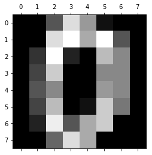

```
[[ 0.  0.  5. 13.  9.  1.  0.  0.]
 [ 0.  0. 13. 15. 10. 15.  5.  0.]
 [ 0.  3. 15.  2.  0. 11.  8.  0.]
 [ 0.  4. 12.  0.  0.  8.  8.  0.]
 [ 0.  5.  8.  0.  0.  9.  8.  0.]
 [ 0.  4. 11.  0.  1. 12.  7.  0.]
 [ 0.  2. 14.  5. 10. 12.  0.  0.]
 [ 0.  0.  6. 13. 10.  0.  0.  0.]]
```

```python
print(labels)  # the labels are printed on the screen
print(digits.keys())  # this command will provide you the key elements in this dataset
print(digits.DESCR)  # to get the descriptive information about this dataset

pl.gray()  # turns an image into gray scale
pl.matshow(digits.images[0])
pl.show()
print(digits.images[0])
```

In the below code , fit the normal digit data. Applied to GaussianNB algorithm and predict it.

```python
# Train-test split is one of the most critical issues in ML
# Try this example with different test size like 0.1 or 0.5
import time
start = time.time()
y = digits.target
X = digits.data
X_train, X_test, y_train, y_test = train_test_split(X, y, test_size=0.3, random_state=10)
X1 = data
X_train1, X_test1, y_train1, y_test1 = train_test_split(X1, y, test_size=0.3, random_state=10)

print(len(X))
print(len(X_train))


gnb = GaussianNB(priors=None)
# gnb = GaussianNB(priors=[0.1, 0.5, 0.05, 0.05, 0.05, 0.05, 0.05, 0.05, 0.05, 0.05])
fit = gnb.fit(X_train, y_train)
predicted = fit.predict(X_test)
print(confusion_matrix(y_test, predicted))
print(accuracy_score(y_test, predicted)) # the use of another function for calculating the accuracy (correct_predictions / all_predictions)
print(accuracy_score(y_test, predicted, normalize=False))  # the number of correct predictions
print(len(predicted))  # the number of all of the predictions
unique_p, counts_p = np.unique(predicted, return_counts=True)
print(unique_p, counts_p)
print((predicted == 0).sum())
print(fit.get_params())
print(fit.predict_proba(X))

done = time.time()
elapsed = done - start
```

```
1797
1257
[[49  1  0  0  1  0  0  0  0  0]
 [ 0 53  1  0  0  0  0  0  3  0]
 [ 0  8 27  8  0  0  0  0 12  0]
 [ 0  0  0 51  0  0  0  1  3  1]
 [ 0  8  0  0 39  1  0  2  1  0]
 [ 0  0  0  1  0 46  0  3  1  0]
 [ 0  1  1  0  0  0 53  0  0  0]
 [ 0  0  0  0  1  0  0 59  0  0]
 [ 0 13  0  1  0  3  0  2 31  0]
 [ 0  2  0  7  0  1  1  9  3 31]]
0.812962962962963
439
540
[0 1 2 3 4 5 6 7 8 9] [49 86 29 68 41 51 54 76 54 32]
49
{'priors': None, 'var_smoothing': 1e-09}
[[1.00000000e+000 1.33287604e-061 1.60690901e-179 ... 2.49662423e-097
  1.13601053e-128 8.46231091e-063]
 [0.00000000e+000 1.00000000e+000 2.76123832e-034 ... 0.00000000e+000
  9.18988933e-019 2.58920112e-059]
 [0.00000000e+000 8.59467989e-001 1.23820991e-016 ... 0.00000000e+000
  1.40532011e-001 3.90395127e-071]
 ...
 [0.00000000e+000 9.99992021e-001 5.29012737e-028 ... 0.00000000e+000
  7.97861676e-006 1.21141946e-061]
 [0.00000000e+000 9.14745635e-002 2.27151003e-047 ... 0.00000000e+000
  5.86793869e-019 9.08525437e-001]
 [0.00000000e+000 0.00000000e+000 3.35211718e-019 ... 0.00000000e+000
  1.00000000e+000 5.34823739e-038]]
```

```python
print(elapsed)
```

```
0.03692936897277832
```

Time Difference : 0.036

Confusion Matrix => Rate of true predict for each color of digit array/image. Accuracy Rate => 0.81 . This result find by diagonal line values / Total Values

In the below code, for the scaled data.

```python
# Train-test split is one of the most critical issues in ML
# Try this example with different test size like 0.1 or 0.5
y = digits.target
X = digits.data
X_train, X_test, y_train, y_test = train_test_split(X, y, test_size=0.3, random_state=10)
X1 = data
X_train1, X_test1, y_train1, y_test1 = train_test_split(X1, y, test_size=0.3, random_state=10)

print(len(X))
print(len(X_train))


gnb = GaussianNB(priors=None)
# gnb = GaussianNB(priors=[0.1, 0.5, 0.05, 0.05, 0.05, 0.05, 0.05, 0.05, 0.05, 0.05])
fit = gnb.fit(X_train1, y_train1)
predicted = fit.predict(X_test1)
print(confusion_matrix(y_test1, predicted))
print(accuracy_score(y_test1, predicted)) # the use of another function for calculating the accuracy (correct_predictions / all_predictions)
print(accuracy_score(y_test1, predicted, normalize=False))  # the number of correct predictions
print(len(predicted))  # the number of all of the predictions
unique_p, counts_p = np.unique(predicted, return_counts=True)
print(unique_p, counts_p)
print((predicted == 0).sum())
print(fit.get_params())
print(fit.predict_proba(X1))
```

```
1797
1257
[[49  2  0  0  0  0  0  0  0  0]
 [ 0 55  0  0  0  0  0  0  2  0]
 [ 0 11 12 22  0  0  0  0 10  0]
 [ 0  0  0 51  0  0  0  1  3  1]
 [ 1 12  0  0 34  1  0  3  0  0]
 [ 0  0  0  1  0 46  0  3  1  0]
 [ 0  1  1  0  0  0 53  0  0  0]
 [ 0  0  0  0  1  0  0 59  0  0]
 [ 0 20  0  1  0  3  0  2 24  0]
 [ 0  6  0  7  0  0  1  8  1 31]]
0.7666666666666667
414
540
[0 1 2 3 4 5 6 7 8 9] [ 50 107  13  82  35  50  54  76  41  32]
50
{'priors': None, 'var_smoothing': 1e-09}
[[1.00000000e+000 4.77679989e-062 1.75037313e-189 ... 8.54617046e-100
  1.36674852e-133 1.19344389e-066]
 [0.00000000e+000 1.00000000e+000 8.39292646e-044 ... 0.00000000e+000
  3.08517769e-023 1.01890224e-062]
 [0.00000000e+000 9.99994511e-001 4.37897221e-026 ... 0.00000000e+000
  5.48925974e-006 1.78747252e-074]
 ...
 [0.00000000e+000 1.00000000e+000 1.60797438e-037 ... 0.00000000e+000
  2.67855766e-010 4.76721623e-065]
 [0.00000000e+000 9.96106778e-001 7.51842376e-056 ... 0.00000000e+000
  2.14515347e-022 3.89322240e-003]
 [0.00000000e+000 0.00000000e+000 3.03500216e-024 ... 0.00000000e+000
  9.99999992e-001 6.26912200e-037]]
```

Confusion Matrix => Rate of true predict for each color of digit array/image. Accuracy Rate => 0.76 . This result find by diagonal line values / Total Values

Accuracy rate was decreased. Because dataset is not normal distributed. So, if the data was scaling, accuracy rate was descreased.

```python
import numpy as np
np.random.seed(42)  # random seeding is performed
digits = load_digits()  # the whole data set with the labels and other information are extracted
n_samples, n_features = data.shape  # the no. of samples and no. of features are determined with the help of shape
n_digits = len(np.unique(digits.target))  # the number of labels are determined with the aid of unique formula
labels = digits.target  # get the ground-truth labels into the labels

print(digits)

print(labels)  # the labels are printed on the screen
print(digits.keys())  # this command will provide you the key elements in this dataset
print(digits.DESCR)  # to get the descriptive information about this dataset
```

[output not shown]

[output cut: 48 more lines]

[output not shown]

SVM algorithm seperate classes for each label. (According to their distances(Ocliddean Distances))

```python
import time
start = time.time()

from sklearn.svm import SVC

y = digits.target
X = digits.data
X_train, X_test, y_train, y_test = train_test_split(X, y, test_size=0.3, random_state=10)
##X_train, X_test, y_train, y_test = train_test_split(X, y, test_size=0.3, random_state=10)
clf = SVC()
clf.fit(X, y)

fit = clf.fit(X_train, y_train)
predicted = fit.predict(X_test)
print(confusion_matrix(y_test, predicted))
print(accuracy_score(y_test, predicted)) # the use of another function for calculating the accuracy (correct_predictions / all_predictions)
print(accuracy_score(y_test, predicted, normalize=False))  # the number of correct predictions
print(len(predicted))  # the number of all of the predictions
unique_p, counts_p = np.unique(predicted, return_counts=True)

SVC(C=1.0, cache_size=200, class_weight=None, coef0=0.0, degree=3, gamma='auto', kernel='linear',
    max_iter=-1, probability=False, random_state=None, shrinking=True, tol=0.001, verbose=False)

done = time.time()
elapsed = done - start
```

```
[[26  0  0  0  0 25  0  0  0  0]
 [ 0 15  0  0  0 42  0  0  0  0]
 [ 0  0 15  0  0 40  0  0  0  0]
 [ 0  0  0 24  0 32  0  0  0  0]
 [ 0  0  0  0 28 23  0  0  0  0]
 [ 0  0  0  0  0 51  0  0  0  0]
 [ 0  0  0  0  0 30 25  0  0  0]
 [ 0  0  0  0  0 48  0 12  0  0]
 [ 0  0  0  0  0 45  0  0  5  0]
 [ 0  0  0  0  0 42  0  0  0 12]]
0.39444444444444443
213
540
```

```python
print(elapsed)
```

```
0.9745965003967285
```